# Multidimensional Scaling

April 26, 2019

## Multidimensional Scaling

- Basic Question: How to represent any data in two dimensions?
1. Projection
2. Squeeze data onto a table: close points stay close.
- Both ideas yield sensible visualization - but show a different aspect of the data.

## Which idea is better?

[figure not shown]

## Idea of MDS

- Represent high-dimensional point cloud in few (usually 2) dimensions keeping distances between points similar.
- Useful tool in visualizing any big data-set, specially for clustering purposes.
- Is a popular exploratory tool. Used before any inferential procedure.

## Goal of MDS

- Given pairwise dissimilarities, reconstruct a map that preserves distances.
- From any dissimilarity (no need to be a metric)
- Reconstructed map has coordinates \(\mathbf{x}_i = (x_{i1}, x_{i2})\) and the natural distance \(\Vert x_i - x_j \Vert^2\).
- MDS is a family of different algorithms, each designed to arrive at optimal low-dimensional configuration (p = 2 or 3)
- Includes: Classical MDS, Metric MDS and Non-metric MDS.

## Examples first - Classical MDS

- Problem: Given Euclidean Distance between points, recover the position of the points.
- Example: Road distance between 21 european cities

```r
library(datasets); class(eurodist)
```

```
## [1] "dist"
```

```
                Athens Barcelona Brussels Calais Cherbourg Cologne
Barcelona         3313
Brussels          2963      1318
Calais            3175      1326      204
Cherbourg         3339      1294      583    460
Cologne           2762      1498      206    409       785
```

## First Try MDS

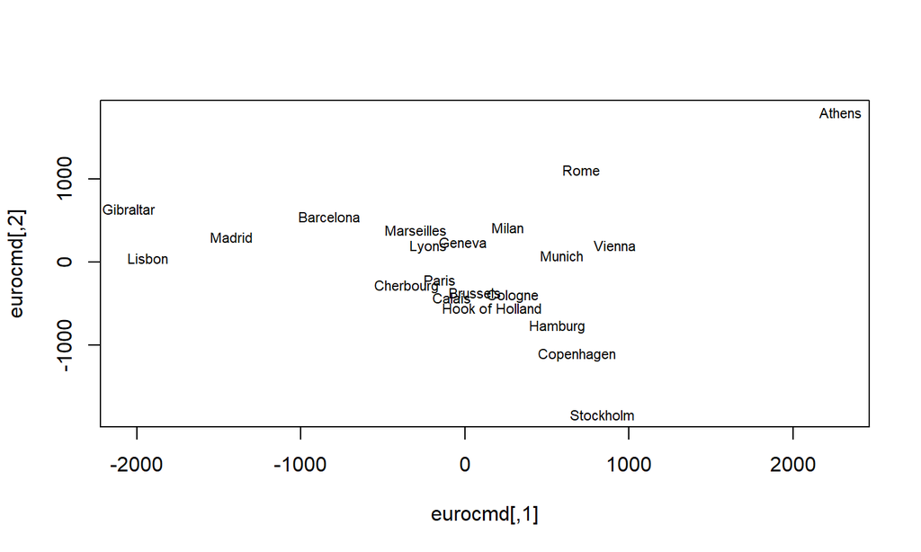

```r
eurocmd <- cmdscale(eurodist)
plot(eurocmd, type = "n")
text(eurocmd, rownames(eurocmd), cex = 0.7)
```

## Do we recover?

[figure not shown]

- Can identify points up to shift, reflection and rotation.

## Flip Axes

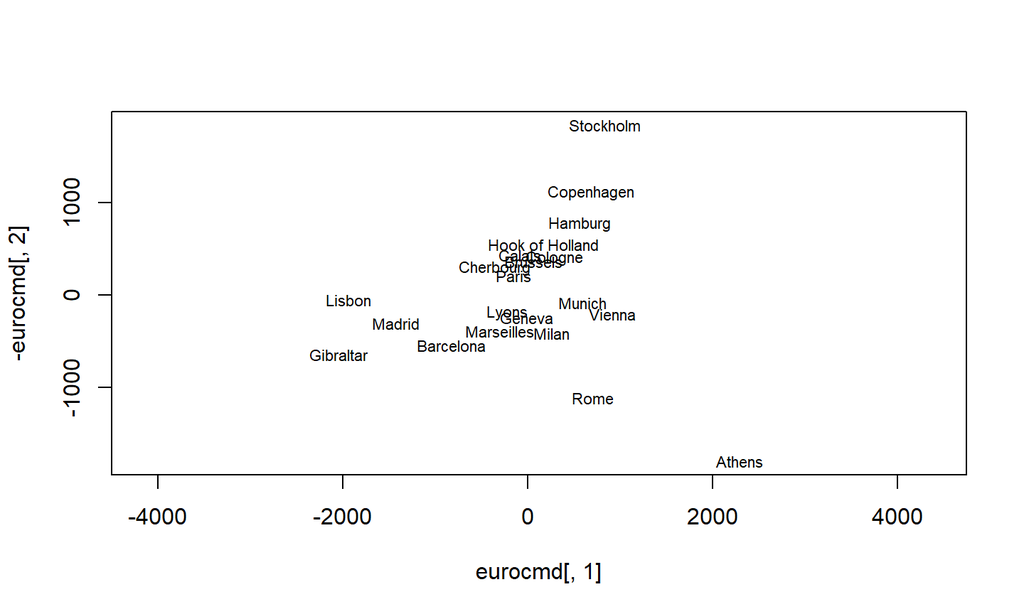

```r
plot(eurocmd[,1], -eurocmd[,2], type = "n", asp = 1)
text(eurocmd[,1], -eurocmd[,2], rownames(eurocmd), cex = 0.7)
```

- Can identify points up to shift, reflection and rotation.

## Another Example

- Air pollution in US Cities

```r
data("USairpollution", package = "HSAUR2")
summary(USairpollution)
```

```
##       SO2              temp            manu            popul
##  Min.   :  8.00   Min.   :43.50   Min.   :  35.0   Min.   :  71.0
##  1st Qu.: 13.00   1st Qu.:50.60   1st Qu.: 181.0   1st Qu.: 299.0
##  Median : 26.00   Median :54.60   Median : 347.0   Median : 515.0
##  Mean   : 30.05   Mean   :55.76   Mean   : 463.1   Mean   : 608.6
##  3rd Qu.: 35.00   3rd Qu.:59.30   3rd Qu.: 462.0   3rd Qu.: 717.0
##  Max.   :110.00   Max.   :75.50   Max.   :3344.0   Max.   :3369.0
##       wind            precip         predays
##  Min.   : 6.000   Min.   : 7.05   Min.   : 36.0
##  1st Qu.: 8.700   1st Qu.:30.96   1st Qu.:103.0
##  Median : 9.300   Median :38.74   Median :115.0
##  Mean   : 9.444   Mean   :36.77   Mean   :113.9
##  3rd Qu.:10.600   3rd Qu.:43.11   3rd Qu.:128.0
##  Max.   :12.700   Max.   :59.80   Max.   :166.0
```

```r
dat <- USairpollution # less typing
```

- Some variables have larger range - need to standardise.

## Try MDS at 2-D

```r
xs <- apply(dat, 2, function(x) (x - min(x))/(diff(range(x))))
poldist <- dist(xs)
pol.mds <- cmdscale(poldist, k = 2, eig = TRUE)
x <- pol.mds$points
pol.mds
```

```
## $points
##                        [,1]         [,2]
## Albany          0.140558172 -0.046859954
## Albuquerque    -0.364824787 -0.636602091
## Atlanta        -0.155922591  0.244511276
## Baltimore       0.153189990  0.067519907
## Buffalo         0.256244063  0.003022604
## Charleston     -0.128730958  0.215783429
## Chicago         1.197000315  0.009638168
## Cincinnati     -0.084166097  0.106828800
## Cleveland       0.531787447  0.056305378
## Columbus        0.025412911  0.033574934
## Dallas         -0.258008194 -0.062640448
## Denver         -0.110682033 -0.510378502
## Des Moines     -0.007603614 -0.244344703
## Detroit         0.341537781 -0.105917971
## Hartford        0.206766531  0.105259858
## Houston        -0.188167760  0.243707765
## Indianapolis    0.069589745  0.010565926
## Jacksonville   -0.349520267  0.412490203
## Kansas City    -0.106424371 -0.085118726
## Little Rock    -0.355970056  0.194004542
## Louisville     -0.046780470  0.144850917
## Memphis        -0.249259311  0.208737990
## Miami          -0.449823739  0.604996816
## Milwaukee       0.217298744 -0.249612250
## Minneapolis     0.326439578 -0.242858309
## Nashville      -0.215002650  0.211835269
## New Orleans    -0.410715158  0.438263300
## Norfolk        -0.066285208  0.149134571
## Omaha          -0.063335982 -0.241936316
## Philadelphia    0.521031706  0.081089446
## Phoenix        -0.695773353 -0.527859295
## Pittsburgh      0.314965899  0.074640031
## Providence      0.466505620  0.110503750
## Richmond       -0.191967563  0.140461889
## Salt Lake City -0.111111665 -0.461383196
## San Francisco  -0.253430076 -0.401897024
## Seattle         0.170829143  0.147411289
## St. Louis       0.162208664 -0.016576959
```

[output cut: 8 more lines]

```
## [16]  6.686099e-17  5.684599e-17  5.034791e-17  4.025565e-17  3.312471e-17
## [21]  2.974204e-17  1.555983e-17  1.132251e-17  3.668800e-18 -5.206488e-18
## [26] -8.948794e-18 -9.519928e-18 -1.506805e-17 -1.853275e-17 -2.314710e-17
## [31] -2.858271e-17 -3.093804e-17 -3.151435e-17 -3.396470e-17 -7.209856e-17
## [36] -7.714641e-17 -1.524915e-16 -2.390840e-16 -2.833661e-16 -3.238640e-16
## [41] -1.263609e-15
##
## $x
## NULL
##
## $ac
## [1] 0
##
## $GOF
## [1] 0.6050889 0.6050889
```

## Plot the 2-D map

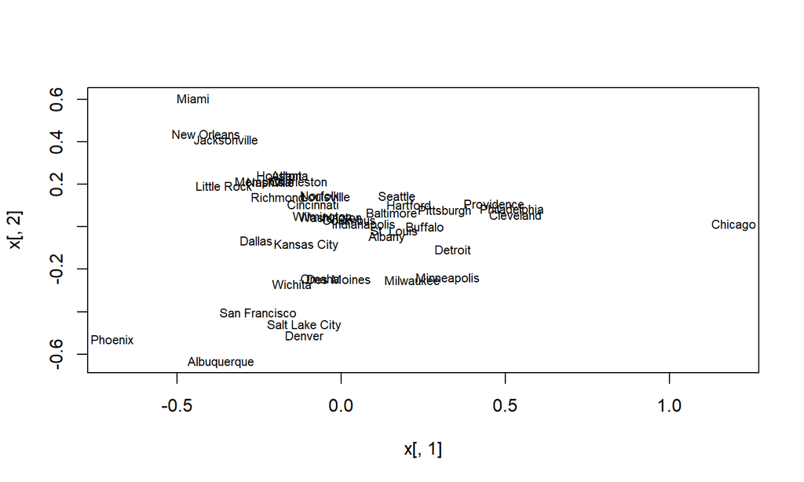

```r
plot(x[,1], x[,2], type = "n")
text(x[,1], x[,2], labels = rownames(x), cex = 0.7)
```

## Star plot

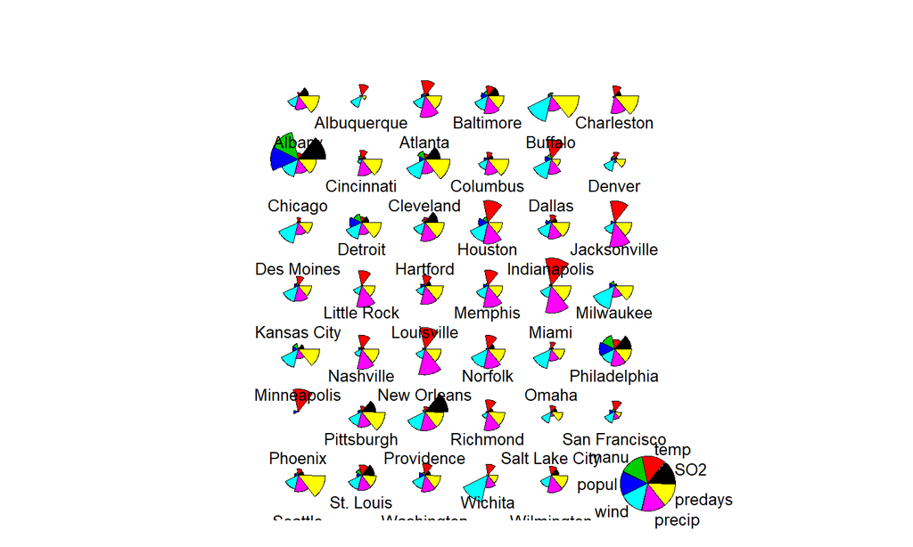

```r
stars(xs, draw.segments = TRUE, key.loc = c(15,2))
```

- Jacksonville and New Orleans have similar profile.

## Thoery of MDS

- Classical MDS: Euclidean distance between \(n\) objects in \(p\) dimensions.
- Output: Position of points upto rotation, reflection, shift.
- Two steps:
1. Compute inner product matrix \(B = X X^T\) from distances.
2. Compute positions from \(B\).

## Distance

- Distance, dissimilarity and similarity (or proximity) are defined for any pair of objects in any space.
- In mathematics, a distance function (that gives a distance between two objects) is also called metric, satisfying:

\[ d(x,y) \ge 0 \\ d(x,y) = 0 \text{ iff } x = y \\ d(x,y) = d(y,x) \\ d(x,z) \le d(x,y) + d(y,z) \]

## Thoery of MDS

- Given a dissimilarity matrix \(D = (d_{ij})\), MDS seeks to find \(x_1, \ldots, x_n \in \mathbb{R}^p\), such that: \[ d_{ij} \approx \Vert x_i - x_j \Vert^2 \text{ as close as possible} \]
- Oftentimes, for some large \(p\), there exists a configuration \(x_1, \ldots, x_n\) with exact distance match \(d_{ij} = \Vert x_i - x_j \Vert^2\).
- In such a case \(d\) is called a Euclidean distance.
- There are, however, cases where the dissimilarity is distance, but there exists no configuration in any \(p\) with perfect match.
- Such a distance is called non-Euclidean distance.

## Thoery (continued)

- Suppose for now we have Euclidean distance matrix \(D = (d_{ij})\)
- We want to find \((x_1, \ldots, x_n)\) such that \(d_{ij} = dist(x_i,x_j)\).
- Not unique solution: \(x^* = x + c\).
- Assume the observations are centered.

## Thoery (hand-waving)

- Find inner product matrix \(B = X X^T\) instead of \(X\).
- Conenct to distance: \(d_{ij}^2 = b_{ii}+b_{jj}-2b_{ij}\).
- Center points to avoid shift invariance.
- Invert relationship: \[ b_{ij} = -1/2(d_{ij}^2 - d_{i.}^2 - d_{.j}^2 + d_{..}^2) \]
- "Doubly centered" distance.

## Thoery

- Since \(B = X X^T\), we need the square-root of \(B\).
- \(B\) is symmetric and positive definite.
- Can be diagonalised: \(B = V \Lambda V^T\).
- \(\Lambda\) is diagonal matrix with eigenvalues \(\lambda_1 > \lambda_2 > \cdots > \lambda_n\)
- Some eignevalues are zero, drop them. \(B = V_1 \Lambda_1 V_1^T\).
- Take "square-root" \(X = V_1 \Lambda_1^T\).

## Classical MDS

- Want a 2-D plot.
- Keep only largest 2 eignevectors and eignevalues.
- The resulting \(X\) will be the low-dimensional representation we were looking for.
- Same for 3-D.

## Random Forest and MDS

```r
library(randomForest)
ind <- sample(2,nrow(iris),replace=TRUE,prob=c(0.7,0.3))
trainData <- iris[ind==1,]
testData <- iris[ind==2,]
iris_rf <- randomForest(Species~.,data=trainData,ntree=100,proximity=TRUE)
table(predict(iris_rf),trainData$Species)
```

```
##
##              setosa versicolor virginica
##   setosa         35          0         0
##   versicolor      0         37         2
##   virginica       0          1        34
```

## Plot the Random Forest

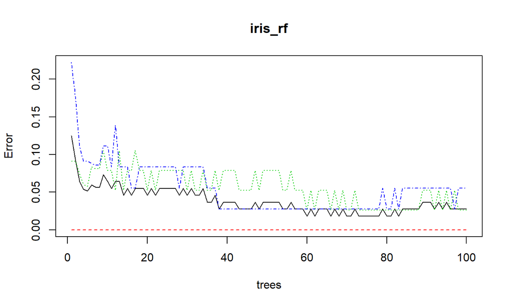

```r
plot(iris_rf)
```

## Variable Importance

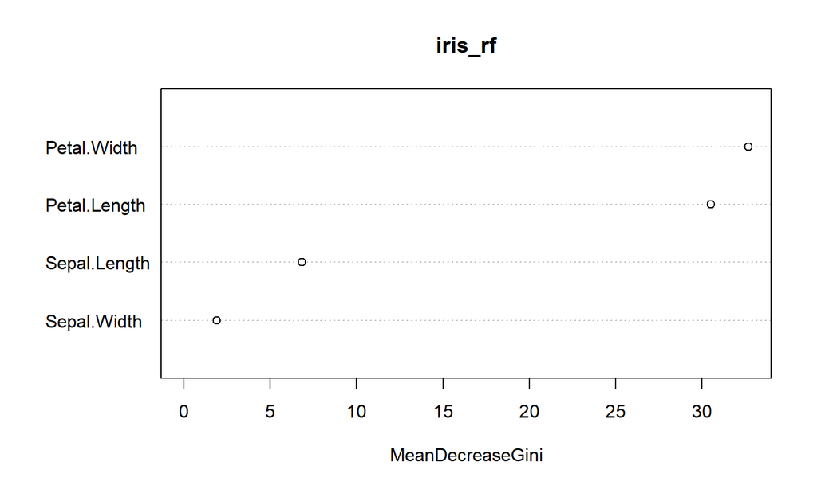

```r
varImpPlot(iris_rf)
```

## Prediction on new data

```r
irisPred<-predict(iris_rf,newdata=testData)
table(irisPred, testData$Species)
```

```
##
## irisPred     setosa versicolor virginica
##   setosa         15          0         0
##   versicolor      0         11         2
##   virginica       0          1        12
```

## Margin of Random Forest

- The margin of a data point is defined as the proportion of votes for the correct class minus maximum proportion of votes for the other classes.
- Thus under majority votes, positive margin means correct classification, and vice versa.

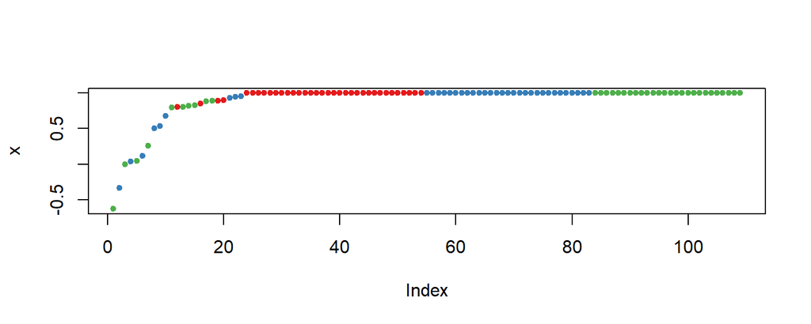

```r
plot(margin(iris_rf,testData$Species))
```

## MDS

- Proximity measure: The \((i,j)\) element of the proximity matrix produced by `randomForest` is the fraction of trees in which elements \(i\) and \(j\) fall in the same terminal node.
- The intuition is that **similar** observations should be in the same terminal nodes more often than dissimilar ones.
- We can use the proximity measure to identify structure.

## MDS on the full Iris Data

```r
set.seed(71)
iris.rf <- randomForest(Species ~ ., data=iris, importance=TRUE,
                        proximity=TRUE)
## Do MDS on 1 - proximity:
iris.mds <- cmdscale(1 - iris.rf$proximity, eig=TRUE)
## Look at variable importance:
round(importance(iris.rf), 2)
```

```
##              setosa versicolor virginica MeanDecreaseAccuracy
## Sepal.Length   5.88       5.87      9.21                10.62
## Sepal.Width    5.23       0.31      4.71                 4.94
## Petal.Length  21.60      31.41     27.71                32.39
## Petal.Width   22.96      33.74     32.07                33.85
##              MeanDecreaseGini
## Sepal.Length             9.37
## Sepal.Width              2.45
## Petal.Length            42.13
## Petal.Width             45.28
```

## Plot the variables

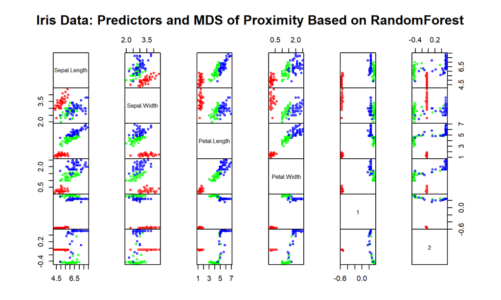

```r
op <- par(pty="s")
pairs(cbind(iris[,1:4], iris.mds$points), cex=0.6, gap=0,
      col=c("red", "green", "blue")[as.numeric(iris$Species)],
      main="Iris Data: Predictors and MDS of Proximity Based on RandomForest")
```

```r
par(op)
```

## Example

- Look at the voting data.
- Are Democrats close to each other, republicans?

```r
data("voting", package = "HSAUR")
require("MASS")
colnames(voting)
```

```
##  [1] "Hunt(R)"           "Sandman(R)"        "Howard(D)"
##  [4] "Thompson(D)"       "Freylinghuysen(R)" "Forsythe(R)"
##  [7] "Widnall(R)"        "Roe(D)"            "Heltoski(D)"
## [10] "Rodino(D)"         "Minish(D)"         "Rinaldo(R)"
## [13] "Maraziti(R)"       "Daniels(D)"        "Patten(D)"
```

## Solution - Metric

```r
voting.mds <- cmdscale(voting, eig=TRUE)
names(voting.mds)
```

```
## [1] "points" "eig"    "x"      "ac"     "GOF"
```

## Plot - Metric

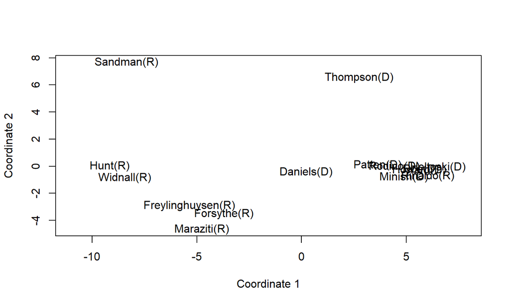

```r
plot(voting.mds$points[,1], voting.mds$points[,2],
     type = "n", xlab = "Coordinate 1", ylab = "Coordinate 2",
     xlim = range(voting.mds$points[,1])*1.2)
text(voting.mds$points[,1], voting.mds$points[,2],
     labels = colnames(voting))
```

## Non-metric

```r
voting_mds <- isoMDS(voting)
```

## Plot

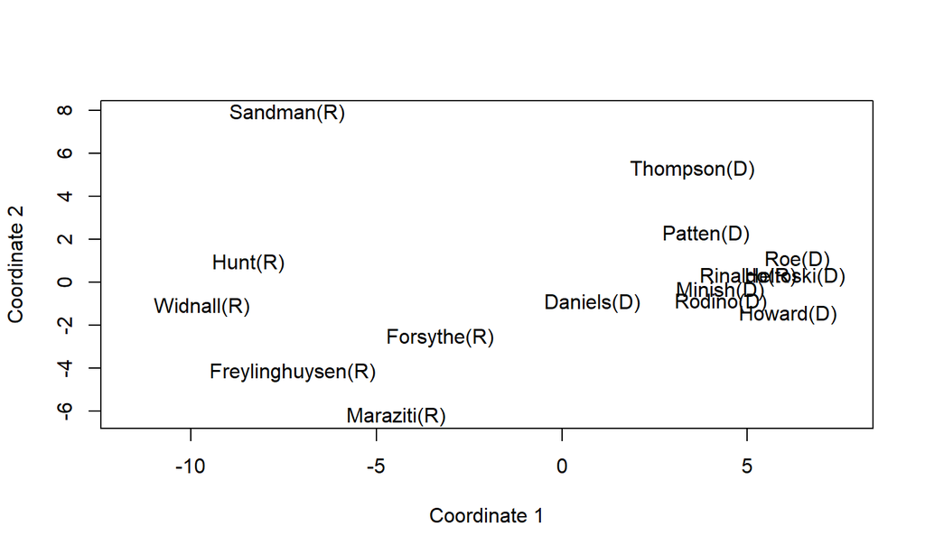

```r
plot(voting_mds$points[,1], voting_mds$points[,2],
     type = "n", xlab = "Coordinate 1", ylab = "Coordinate 2",
     xlim = range(voting_mds$points[,1])*1.2)
text(voting_mds$points[,1], voting_mds$points[,2],
     labels = colnames(voting))
```